# Lab 10

Sarah Roffo

## Question 1

Use R package UScensus2010county to complete the following tasks: (20 pt.)

### Question 1(a)

Plot a map of New York counties using the plot function.

```r
library(UScensus2010)
if(!require(UScensus2010county)) install.county("osx")
```

[output not shown]

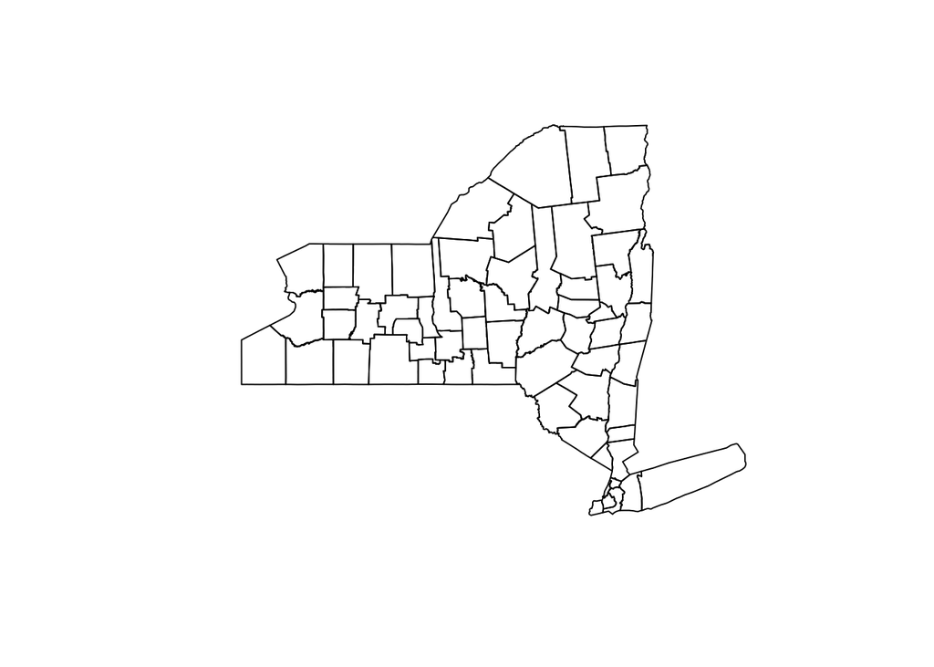

```r
library(UScensus2010county)
data(new_york.county10)
shp <- new_york.county10
plot(shp)
```

### Question 1(b)

Plot a map of New York counties using the qtm function.

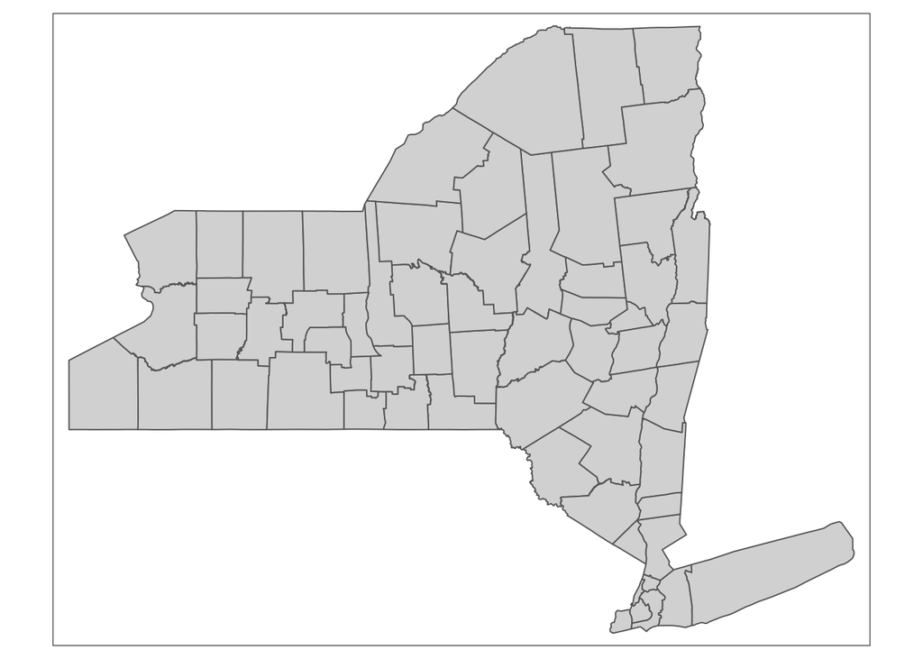

```r
library(tmap)
qtm(shp)
```

### Question 1(c)

How many counties in New York State?

```r
df1 <- shp@data
nrow(df1)
```

```
## [1] 62
```

```r
print('There are 62 counties in New York State')
```

```
## [1] "There are 62 counties in New York State"
```

### Question 1(d)

What’s the 3-digit fips code of Broome County?

```r
df1[df1$NAME10 == "Broome",]
```

[output not shown]

[output cut: 99 more lines]

[output not shown]

```r
print('The fips code of Broome County is 007 -- the last three digits of the fips column')
```

```
## [1] "The fips code of Broome County is 007 -- the last three digits of the fips column"
```

### Question 1(e)

Compute descriptive statistics of the population column (P0010001), including total, minimum, maximum, mean, median, and skewness.

```r
df1 <- shp@data
min(df1$P0010001)
```

```
## [1] 4836
```

```r
max(df1$P0010001)
```

```
## [1] 2504700
```

```r
mean(df1$P0010001)
```

```
## [1] 312550
```

```r
median(df1$P0010001)
```

```
## [1] 91301
```

```r
library(e1071)
skewness(df1$P0010001)
```

```
## [1] 2.517639
```

### Question 1(f)

Create a histogram and a boxplot of the population.

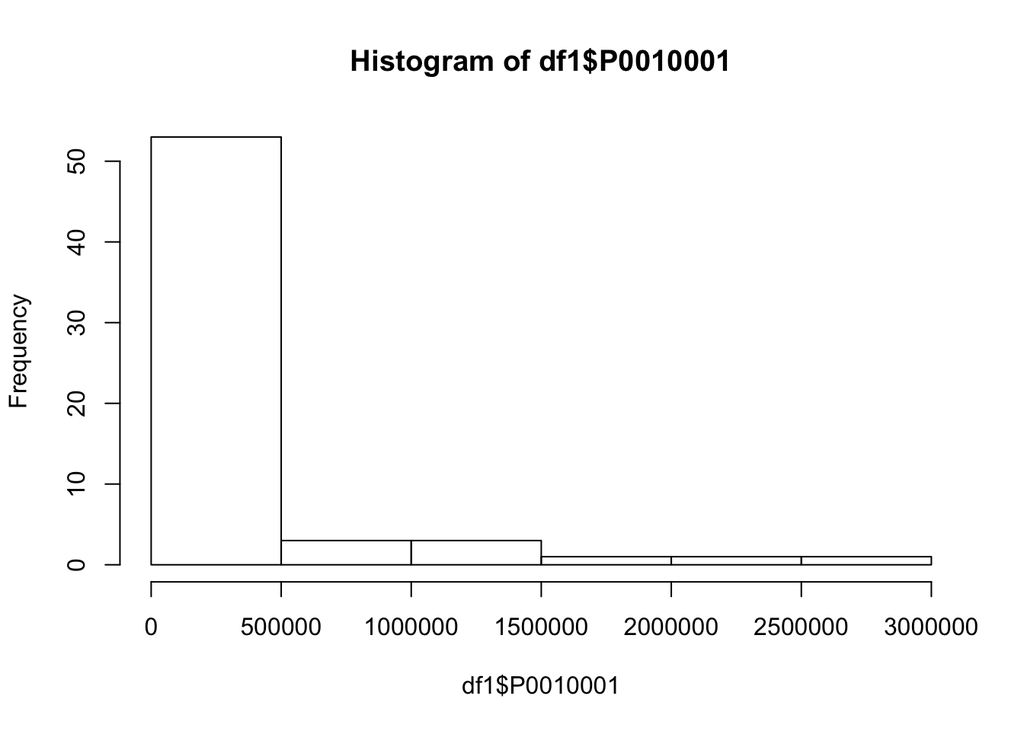

```r
hist(df1$P0010001)
```

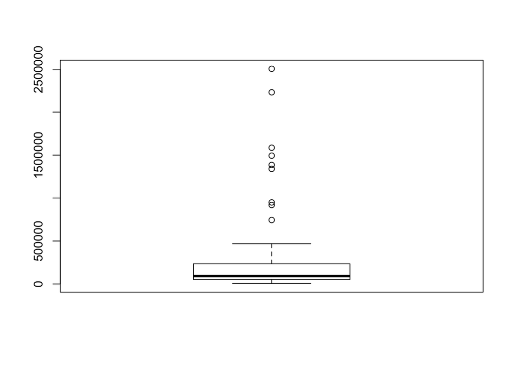

```r
boxplot(df1$P0010001)
```

## Question 2

Use R package UScensus2010tract to complete the following tasks: (20 pt.)

### Question 2(a)

Plot a map of New York census tracts using the plot function.

```r
library(UScensus2010)
if(!require(UScensus2010tract)) install.tract("osx")
```

[output not shown]

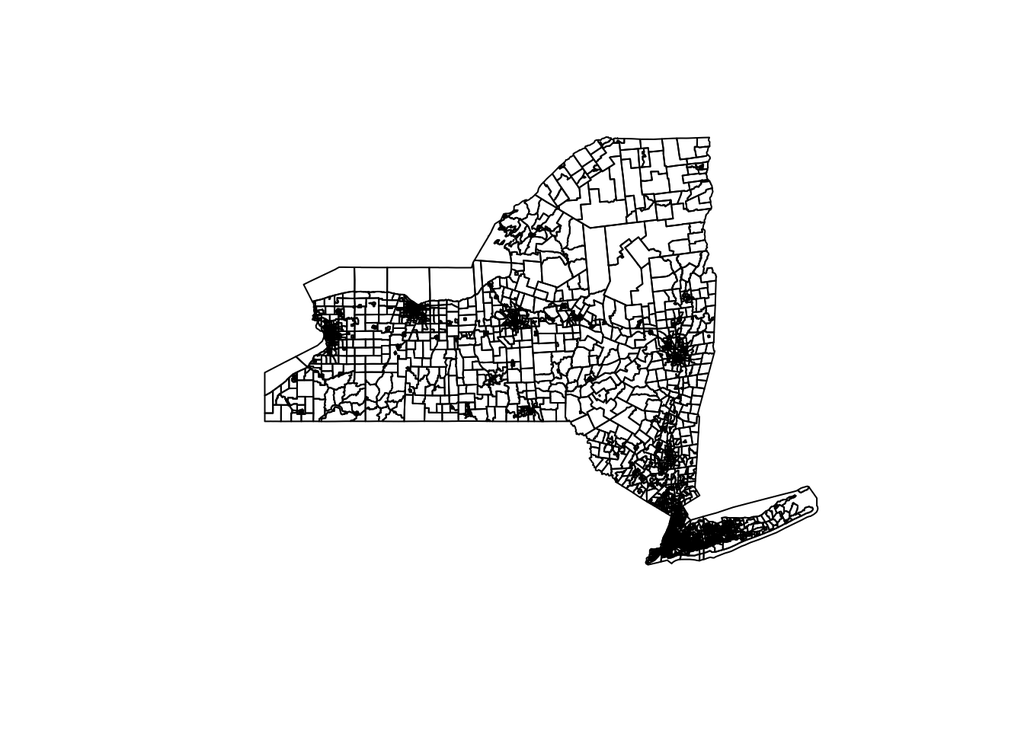

```r
library(UScensus2010tract)
data(new_york.tract10)
shp <- new_york.tract10
plot(shp)
```

### Question 2(b)

Compute the total population based on census tracts.

```r
df2 <- shp@data
pop <- df2$P0010001
sum(pop)
```

```
## [1] 19378102
```

```r
print('The total population of New York State based on census tracts is 19,378,102.')
```

```
## [1] "The total population of New York State based on census tracts is 19,378,102."
```

### Question 2(c)

Select all census tracts in Broome County and plot the map.

```r
df3 <- df2[df2$county == "007",]
shp <- df3
#plot(df2[df2$county == "007",])
```

[output not shown]

[output not shown]

### Question 2(d)

What’s the total population of Broome County?

```r
df3 <- df2[df2$county == "007",]
total.pop <- sum(df3$P0010001)
sum(total.pop)
```

```
## [1] 200600
```

```r
print('The total population of Broome County is 200,600.')
```

```
## [1] "The total population of Broome County is 200,600."
```

### Question 2(e)

Create a histogram and a boxplot of population based on census tracts of Broome County.

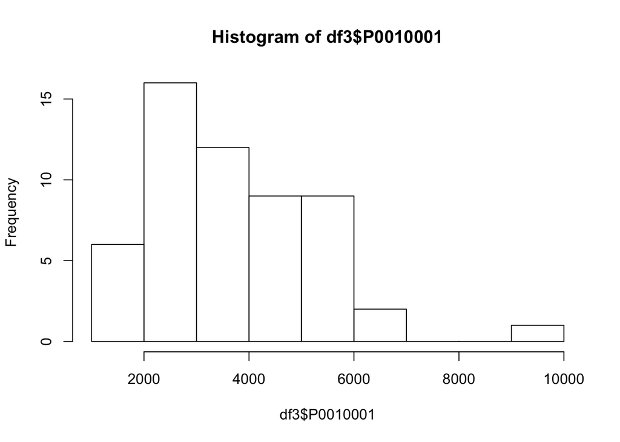

```r
hist(df3$P0010001)
```

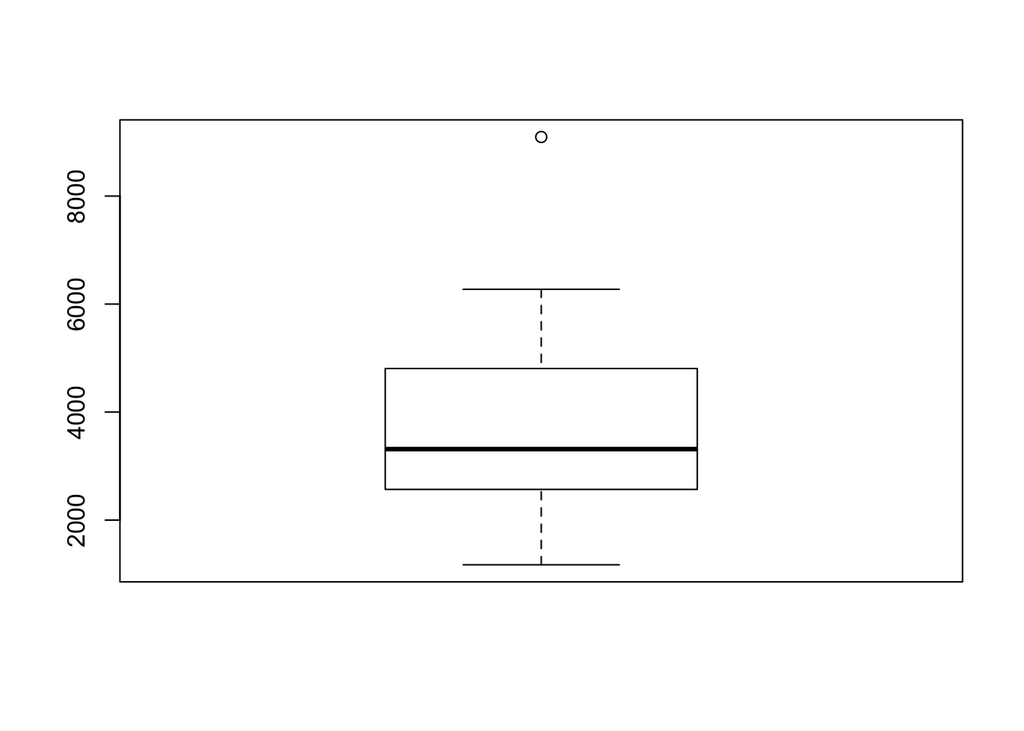

```r
boxplot(df3$P0010001)
```

### Question 2(f)

Select the first five columns of the shapefile of Broome County census tract; add a new population ratio column (= census tract population / county population); save the new shapefile to the hard drive.

```r
library(rgdal)
shape <- shp[,1:5]
shape
```

```
##                      state county  tract        fips P0010001
## new_york.tract10_22     36    007 012500 36007012500     6274
## new_york.tract10_46     36    007 011902 36007011902     2732
## new_york.tract10_47     36    007 000100 36007000100     3220
## new_york.tract10_48     36    007 000200 36007000200     3188
## new_york.tract10_49     36    007 000300 36007000300     2975
## new_york.tract10_50     36    007 000400 36007000400     2356
## new_york.tract10_51     36    007 000500 36007000500     1969
## new_york.tract10_52     36    007 000600 36007000600     2296
## new_york.tract10_53     36    007 000700 36007000700     3684
## new_york.tract10_54     36    007 000900 36007000900     1762
## new_york.tract10_55     36    007 001100 36007001100     1689
## new_york.tract10_56     36    007 001200 36007001200     1173
## new_york.tract10_57     36    007 001300 36007001300     2762
## new_york.tract10_58     36    007 001400 36007001400     5074
## new_york.tract10_59     36    007 001500 36007001500     4672
## new_york.tract10_60     36    007 001600 36007001600     2389
## new_york.tract10_61     36    007 001700 36007001700     4081
## new_york.tract10_62     36    007 001800 36007001800     4086
## new_york.tract10_63     36    007 012702 36007012702     4942
## new_york.tract10_64     36    007 012101 36007012101     3817
## new_york.tract10_65     36    007 012102 36007012102     4024
## new_york.tract10_66     36    007 012103 36007012103     3411
## new_york.tract10_67     36    007 014302 36007014302     9094
## new_york.tract10_68     36    007 012300 36007012300     5232
## new_york.tract10_69     36    007 012701 36007012701     5441
## new_york.tract10_76     36    007 012800 36007012800     5278
## new_york.tract10_77     36    007 012201 36007012201     2521
## new_york.tract10_78     36    007 012202 36007012202     4153
## new_york.tract10_79     36    007 012600 36007012600     5857
## new_york.tract10_80     36    007 011903 36007011903     2751
## new_york.tract10_81     36    007 012000 36007012000     1672
## new_york.tract10_82     36    007 012400 36007012400     2407
## new_york.tract10_95     36    007 011901 36007011901     2946
## new_york.tract10_96     36    007 012900 36007012900     1532
## new_york.tract10_97     36    007 013000 36007013000     4391
## new_york.tract10_98     36    007 013301 36007013301     4979
## new_york.tract10_112    36    007 013303 36007013303     2768
## new_york.tract10_113    36    007 013304 36007013304     6039
## new_york.tract10_114    36    007 013700 36007013700     3299
## new_york.tract10_115    36    007 013400 36007013400     4337
## new_york.tract10_116    36    007 013500 36007013500     2018
## new_york.tract10_117    36    007 013600 36007013600     3738
## new_york.tract10_118    36    007 013100 36007013100     2617
## new_york.tract10_119    36    007 013201 36007013201     2269
## new_york.tract10_136    36    007 013202 36007013202     3189
## new_york.tract10_137    36    007 013800 36007013800     3475
## new_york.tract10_138    36    007 013900 36007013900     2352
## new_york.tract10_139    36    007 014000 36007014000     3118
## new_york.tract10_140    36    007 014100 36007014100     3449
## new_york.tract10_141    36    007 014200 36007014200     2776
## new_york.tract10_142    36    007 014301 36007014301     5305
## new_york.tract10_143    36    007 010200 36007010200     5377
## new_york.tract10_144    36    007 014400 36007014400     5064
## new_york.tract10_145    36    007 014500 36007014500     3315
## new_york.tract10_146    36    007 014600 36007014600     5265
```

```r
shape$pop <- shape$P0010001/sum(shape$P0010001)
shape
```

[output not shown]

```
##                      state county  tract        fips P0010001         pop
## new_york.tract10_22     36    007 012500 36007012500     6274 0.031276171
## new_york.tract10_46     36    007 011902 36007011902     2732 0.013619143
## new_york.tract10_47     36    007 000100 36007000100     3220 0.016051844
## new_york.tract10_48     36    007 000200 36007000200     3188 0.015892323
## new_york.tract10_49     36    007 000300 36007000300     2975 0.014830508
## new_york.tract10_50     36    007 000400 36007000400     2356 0.011744766
## new_york.tract10_51     36    007 000500 36007000500     1969 0.009815553
## new_york.tract10_52     36    007 000600 36007000600     2296 0.011445663
## new_york.tract10_53     36    007 000700 36007000700     3684 0.018364905
## new_york.tract10_54     36    007 000900 36007000900     1762 0.008783649
## new_york.tract10_55     36    007 001100 36007001100     1689 0.008419741
## new_york.tract10_56     36    007 001200 36007001200     1173 0.005847458
## new_york.tract10_57     36    007 001300 36007001300     2762 0.013768694
## new_york.tract10_58     36    007 001400 36007001400     5074 0.025294118
## new_york.tract10_59     36    007 001500 36007001500     4672 0.023290130
## new_york.tract10_60     36    007 001600 36007001600     2389 0.011909272
## new_york.tract10_61     36    007 001700 36007001700     4081 0.020343968
## new_york.tract10_62     36    007 001800 36007001800     4086 0.020368893
## new_york.tract10_63     36    007 012702 36007012702     4942 0.024636092
## new_york.tract10_64     36    007 012101 36007012101     3817 0.019027916
## new_york.tract10_65     36    007 012102 36007012102     4024 0.020059821
## new_york.tract10_66     36    007 012103 36007012103     3411 0.017003988
## new_york.tract10_67     36    007 014302 36007014302     9094 0.045333998
## new_york.tract10_68     36    007 012300 36007012300     5232 0.026081755
## new_york.tract10_69     36    007 012701 36007012701     5441 0.027123629
## new_york.tract10_76     36    007 012800 36007012800     5278 0.026311067
## new_york.tract10_77     36    007 012201 36007012201     2521 0.012567298
## new_york.tract10_78     36    007 012202 36007012202     4153 0.020702891
## new_york.tract10_79     36    007 012600 36007012600     5857 0.029197408
## new_york.tract10_80     36    007 011903 36007011903     2751 0.013713858
## new_york.tract10_81     36    007 012000 36007012000     1672 0.008334995
## new_york.tract10_82     36    007 012400 36007012400     2407 0.011999003
## new_york.tract10_95     36    007 011901 36007011901     2946 0.014685942
## new_york.tract10_96     36    007 012900 36007012900     1532 0.007637089
## new_york.tract10_97     36    007 013000 36007013000     4391 0.021889332
## new_york.tract10_98     36    007 013301 36007013301     4979 0.024820538
## new_york.tract10_112    36    007 013303 36007013303     2768 0.013798604
## new_york.tract10_113    36    007 013304 36007013304     6039 0.030104686
## new_york.tract10_114    36    007 013700 36007013700     3299 0.016445663
## new_york.tract10_115    36    007 013400 36007013400     4337 0.021620140
## new_york.tract10_116    36    007 013500 36007013500     2018 0.010059821
## new_york.tract10_117    36    007 013600 36007013600     3738 0.018634098
## new_york.tract10_118    36    007 013100 36007013100     2617 0.013045862
## new_york.tract10_119    36    007 013201 36007013201     2269 0.011311067
## new_york.tract10_136    36    007 013202 36007013202     3189 0.015897308
## new_york.tract10_137    36    007 013800 36007013800     3475 0.017323031
## new_york.tract10_138    36    007 013900 36007013900     2352 0.011724826
## new_york.tract10_139    36    007 014000 36007014000     3118 0.015543370
## new_york.tract10_140    36    007 014100 36007014100     3449 0.017193420
## new_york.tract10_141    36    007 014200 36007014200     2776 0.013838485
## new_york.tract10_142    36    007 014301 36007014301     5305 0.026445663
## new_york.tract10_143    36    007 010200 36007010200     5377 0.026804586
## new_york.tract10_144    36    007 014400 36007014400     5064 0.025244267
## new_york.tract10_145    36    007 014500 36007014500     3315 0.016525424
## new_york.tract10_146    36    007 014600 36007014600     5265 0.026246261
```

## Question 3

Use R packages raster and ncdf4 to complete the following tasks: (20 pt.)

```r
library(raster)
library(ncdf4)
```

### Question 3(a)

Load the multi-band raster dataset “NDVI.nc” into R.

```r
NDVI_RB <- brick("NDVI.nc")
NDVI_RB
```

```
## class       : RasterBrick
## dimensions  : 360, 720, 259200, 36  (nrow, ncol, ncell, nlayers)
## resolution  : 0.5, 0.5  (x, y)
## extent      : -180, 180, -90, 90  (xmin, xmax, ymin, ymax)
## coord. ref. : +proj=longlat +datum=WGS84 +ellps=WGS84 +towgs84=0,0,0
## data source : /Users/sarahroffo/Desktop/GEOG 533 - Statistics/Labs/Roffo_Sarah_Lab10/NDVI.nc
## names       : X2000.01.01, X2000.02.01, X2000.03.01, X2000.04.01, X2000.05.01, X2000.06.01, X2000.07.01, X2000.08.01, X2000.09.01, X2000.10.01, X2000.11.01, X2000.12.01, X2001.01.01, X2001.02.01, X2001.03.01, ...
## Date        : 2000-01-01, 2002-12-01 (min, max)
## varname     : NDVI
```

### Question 3(b)

Get the basic information about the dataset, including the number of rows, columns, cells, and bands; spatial resolution, extent, bounding box, and projection.

```r
nrow(NDVI_RB)
```

```
## [1] 360
```

```r
ncol(NDVI_RB)
```

```
## [1] 720
```

```r
ncell(NDVI_RB)
```

```
## [1] 259200
```

```r
nbands(NDVI_RB)
```

```
## [1] 36
```

```r
res(NDVI_RB)
```

```
## [1] 0.5 0.5
```

```r
extent(NDVI_RB)
```

```
## class       : Extent
## xmin        : -180
## xmax        : 180
## ymin        : -90
## ymax        : 90
```

```r
bbox(NDVI_RB)
```

```
##     min max
## s1 -180 180
## s2  -90  90
```

```r
projection(NDVI_RB)
```

```
## [1] "+proj=longlat +datum=WGS84 +ellps=WGS84 +towgs84=0,0,0"
```

### Question 3(c)

Aggregate all bands to generate a mean NDVI raster and a maximum NDVI raster; save the two new raster datasets to the hard drive.

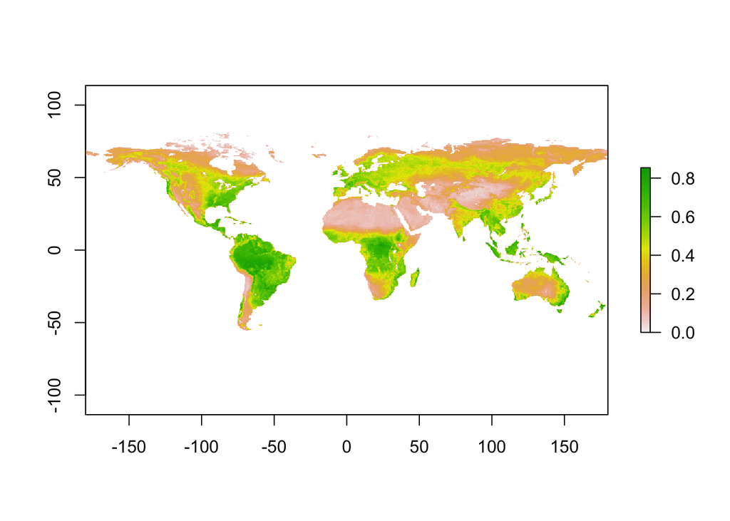

```r
mean_NDVI <- mean(NDVI_RB)
plot(mean_NDVI)
```

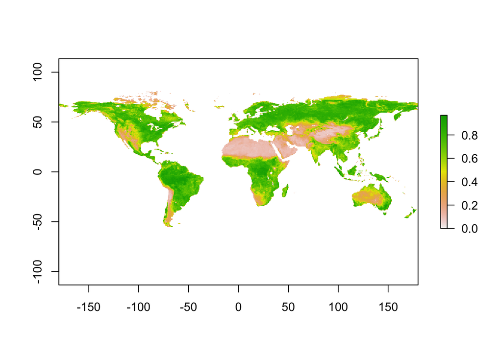

```r
max_NDVI <- max(NDVI_RB)
plot(max_NDVI)
```

```r
writeRaster(x = mean_NDVI, filename = "mean_NDVI.tif", overwrite = TRUE)
writeRaster(x = max_NDVI, filename = "max_NDVI.tif", overwrite = TRUE)
```

### Question 3(d)

Plot the maps of monthly NDVI of the year 2001

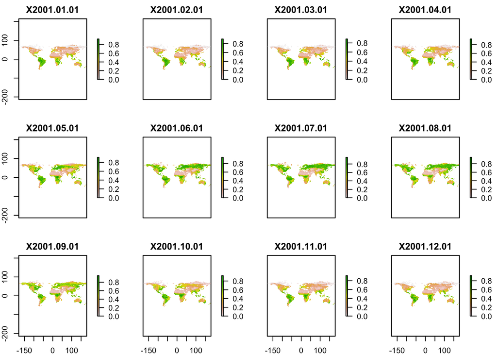

```r
monthly_2001 <- NDVI_RB[[13:24]]
plot(monthly_2001)
```

### Question 3(e)

Create histograms of monthly NDVI of the year 2001.

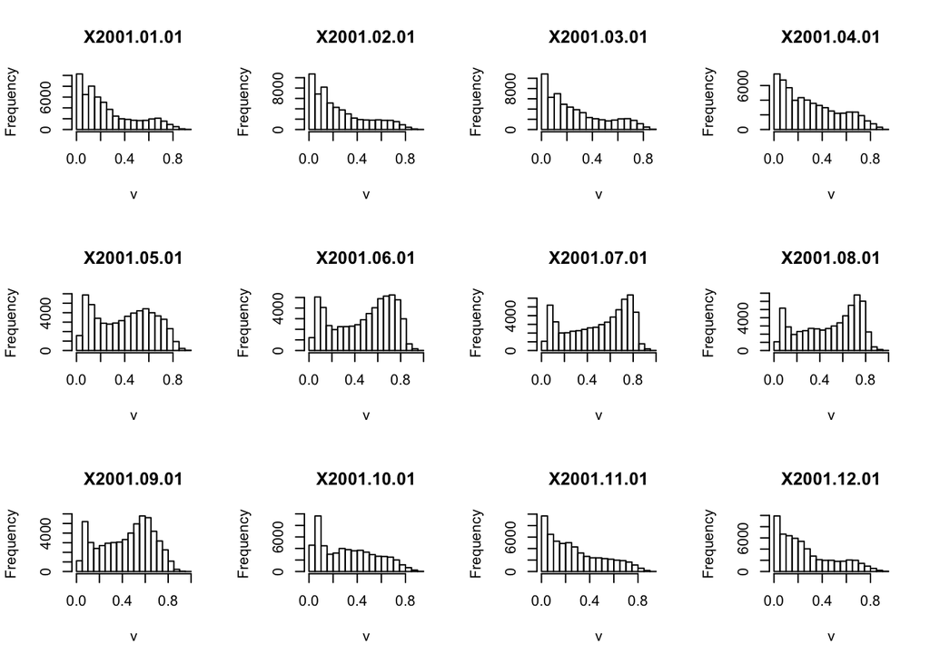

```r
hist(monthly_2001)
```

### Question 3(f)

Plot the NDVI map of July 2000; click any location with data on the map and retrieve the NDVI time series for all years; plot the NDVI time series of the selected location.

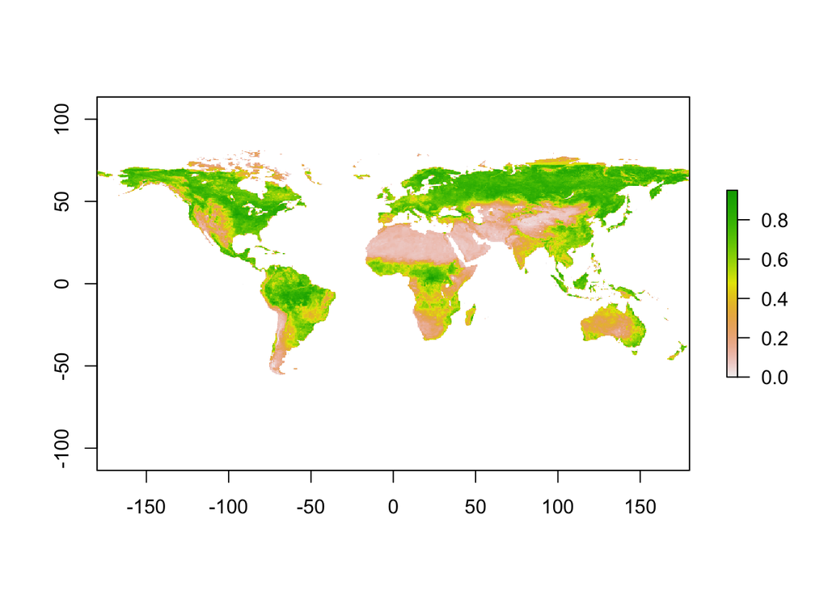

```r
plot(NDVI_RB[[7]])
```

```r
values <- NDVI_RB[150, 50]
```

[output not shown]